# COVID-19 Analysis Project

Leah Paredes

## Introduction

[figure not shown]

The COVID-19 outbreak was a global public health emergency that affected people’s lives all over the world. COVID-19 is an infectious disease caused by the SARS-CoV2 virus that spread from person to person most commonly through droplet transmission. Once a person tested positive they could develop a variety of symptoms ranging from mild to severe ([WHO](https://www.who.int/health-topics/coronavirus#tab=tab_1)). In an effort to slow the rapid spread, many public health officials called for stay at home orders which forced non-essential workers to shelter at home. The pandemic led to huge loss of life, increased poverty, and economic loss ([Ciotti](https://www.tandfonline.com/doi/full/10.1080/10408363.2020.1783198#abstract)). It was an event that lead the world to think about responsibility public health offices have when dealing with a pandemic.

### Why it Matters?

Although one might think the same measures were used throughout the entire country, every state in our country had the ability to implement their own measures to help curb the spread of the virus. States were allowed to determine testing sites, mask mandates, stay-at-home orders, isolation periods, etc. The differences across states had lasting impacts on the people living there. When research of state measures is conducted in combination with state data we can come see which states had lower positives tests. Did states with more restrictive measures have lower positive test? Hospitalizations? Deaths? How can we use state data in the event of another pandemic. Our project will compare the COVID-19 data for two states and see how their infection rates differed.

## Accessing Our Data

In order to access the data of interest, we used an API which provides access to national and state data regarding COVID-19. The initial website used is [Covid-API](https://covidtracking.com/data/api). This website is run by The COVID Tracking Project, a volunteer organization launched by The Atlantic that collected and published state data regarding the COVID-19 outbreak. This is an Open API, which means that it’s open for public use. There were parameters available regarding specific dates as well as states, and while we’re focused on the states of Alabama and Washington, we want to access all historic data on all available states.

We use the `GET` function access the API and store the response into `res`. `res` stores the data as Unicode so we convert it to a JOSN character list containing all our requested data.

```r
res <- GET("https://api.covidtracking.com/v1/states/daily.json")
states_data <- fromJSON(rawToChar(res$content))
```

## Exploratory Data Analysis

Exploratory data analysis (EDA) is an essential part of the analysis process. It gives us insight into the data we have at hand, identify possible problems, and allow us to see what we have to work with when it comes to our analysis. Initially we should look at the amount of variables within `states_data`.

```r
names(states_data)
```

```
##  [1] "date"                        "state"
##  [3] "positive"                    "probableCases"
##  [5] "negative"                    "pending"
##  [7] "totalTestResultsSource"      "totalTestResults"
##  [9] "hospitalizedCurrently"       "hospitalizedCumulative"
## [11] "inIcuCurrently"              "inIcuCumulative"
## [13] "onVentilatorCurrently"       "onVentilatorCumulative"
## [15] "recovered"                   "lastUpdateEt"
## [17] "dateModified"                "checkTimeEt"
## [19] "death"                       "hospitalized"
## [21] "hospitalizedDischarged"      "dateChecked"
## [23] "totalTestsViral"             "positiveTestsViral"
## [25] "negativeTestsViral"          "positiveCasesViral"
## [27] "deathConfirmed"              "deathProbable"
## [29] "totalTestEncountersViral"    "totalTestsPeopleViral"
## [31] "totalTestsAntibody"          "positiveTestsAntibody"
## [33] "negativeTestsAntibody"       "totalTestsPeopleAntibody"
## [35] "positiveTestsPeopleAntibody" "negativeTestsPeopleAntibody"
## [37] "totalTestsPeopleAntigen"     "positiveTestsPeopleAntigen"
## [39] "totalTestsAntigen"           "positiveTestsAntigen"
## [41] "fips"                        "positiveIncrease"
## [43] "negativeIncrease"            "total"
## [45] "totalTestResultsIncrease"    "posNeg"
## [47] "dataQualityGrade"            "deathIncrease"
## [49] "hospitalizedIncrease"        "hash"
## [51] "commercialScore"             "negativeRegularScore"
## [53] "negativeScore"               "positiveScore"
## [55] "score"                       "grade"
```

Looking at this we can see there are 56 separate variables! This is a lot of different variables and we most likely will not need most of them, but it’s important to see what they were and what they represent. When we look at the Covid Tracking Project website we can cross reference the variables and see what they represent and if they will be useful.

We can see from the figure above that there are 56 individual variables. Although there are many variables, not every single one will be useful for our analysis. When you reference the API access site and our `states_data` you’re able to see all the variables are listed with a brief description of each one.

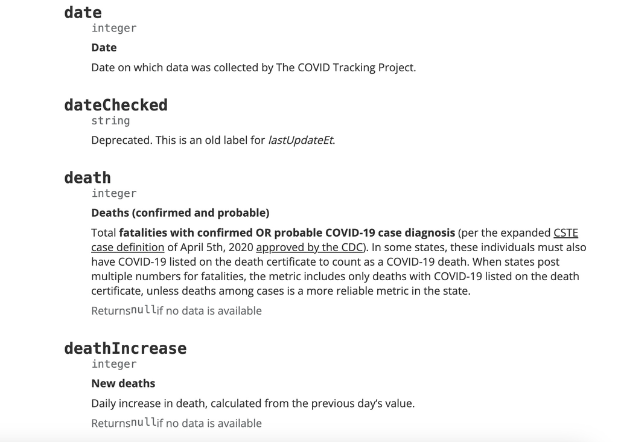

We can see that we have a variable representing each state, but upon further inspection we notice that it also includes US territories.

```r
unique(states_data$state)
```

```
##  [1] "AK" "AL" "AR" "AS" "AZ" "CA" "CO" "CT" "DC" "DE" "FL" "GA" "GU" "HI" "IA"
## [16] "ID" "IL" "IN" "KS" "KY" "LA" "MA" "MD" "ME" "MI" "MN" "MO" "MP" "MS" "MT"
## [31] "NC" "ND" "NE" "NH" "NJ" "NM" "NV" "NY" "OH" "OK" "OR" "PA" "PR" "RI" "SC"
## [46] "SD" "TN" "TX" "UT" "VA" "VI" "VT" "WA" "WI" "WV" "WY"
```

We also know there is a variable regarding the dates of all the observations and from the API site we know there was data collection from January 2020 and March 2021. We do not know if each state and territory have the same amount of observations during this period.

We start by grouping the states observations and then seeing the amount of observations each state has.

```r
date_recorded <- states_data %>%
  group_by(state) %>%
  count()

date_recorded %>%
  kbl() %>%
  scroll_box(width = "300px", height = "400px")
```

| state | n |
| --- | --- |
| AK | 367 |
| AL | 366 |
| AR | 367 |
| AS | 357 |
| AZ | 369 |
| CA | 369 |
| CO | 369 |
| CT | 373 |
| DC | 368 |
| DE | 367 |
| FL | 404 |
| GA | 369 |
| GU | 357 |
| HI | 369 |
| IA | 367 |
| ID | 366 |
| IL | 369 |
| IN | 375 |
| KS | 367 |
| KY | 367 |
| LA | 366 |
| MA | 411 |
| MD | 368 |
| ME | 366 |
| MI | 372 |
| MN | 367 |
| MO | 366 |
| MP | 357 |
| MS | 366 |
| MT | 366 |
| NC | 369 |
| ND | 366 |
| NE | 387 |
| NH | 369 |
| NJ | 392 |
| NM | 368 |
| NV | 368 |
| NY | 371 |
| OH | 368 |
| OK | 366 |
| OR | 369 |
| PA | 370 |
| PR | 357 |
| RI | 372 |
| SC | 369 |
| SD | 366 |
| TN | 368 |
| TX | 370 |
| UT | 366 |
| VA | 406 |
| VI | 357 |
| VT | 370 |
| WA | 420 |
| WI | 370 |
| WV | 367 |
| WY | 372 |

Now for us to be able to better analyze the data we are going to arrange the states from the largest number of observations to the lowest number of observations.

```r
date_recorded %>%
  arrange(n)
```

```
## # A tibble: 56 × 2
## # Groups:   state [56]
##    state     n
##    <chr> <int>
##  1 AS      357
##  2 GU      357
##  3 MP      357
##  4 PR      357
##  5 VI      357
##  6 AL      366
##  7 ID      366
##  8 LA      366
##  9 ME      366
## 10 MO      366
## # ℹ 46 more rows
```

To visualize the data we are working with we are going to graph the 6 states with the highest amount of observations and the 6 states with the lowest amount of observations.

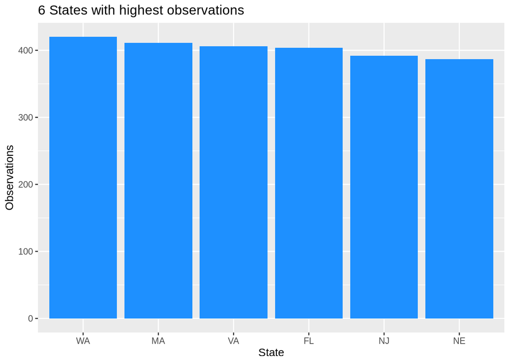

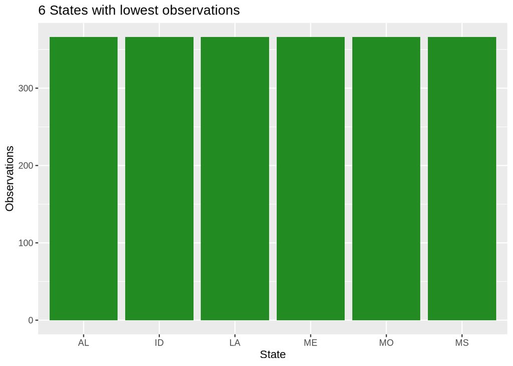

```r
date_recorded %>%
  arrange(desc(n)) %>%
  head() %>%
  ggplot(aes(x =reorder(state, -n), y = n)) +
  geom_bar(stat = "identity", fill = "dodgerblue") +
  labs(
    title = "6 States with highest observations",
    x = "State",
    y = "Observations"
  )

date_recorded %>%
  filter(!state %in% c("AS","GU","MP","VI", "VT", "PR")) %>% #removing included territories
  arrange(n) %>%
  head() %>%
  ggplot(aes(x=reorder(state, n), y = n)) +
  geom_bar(stat = "identity", fill = "forestgreen") +
  labs(
    title = "6 States with lowest observations",
    x = "State",
    y = "Observations"
  )
```

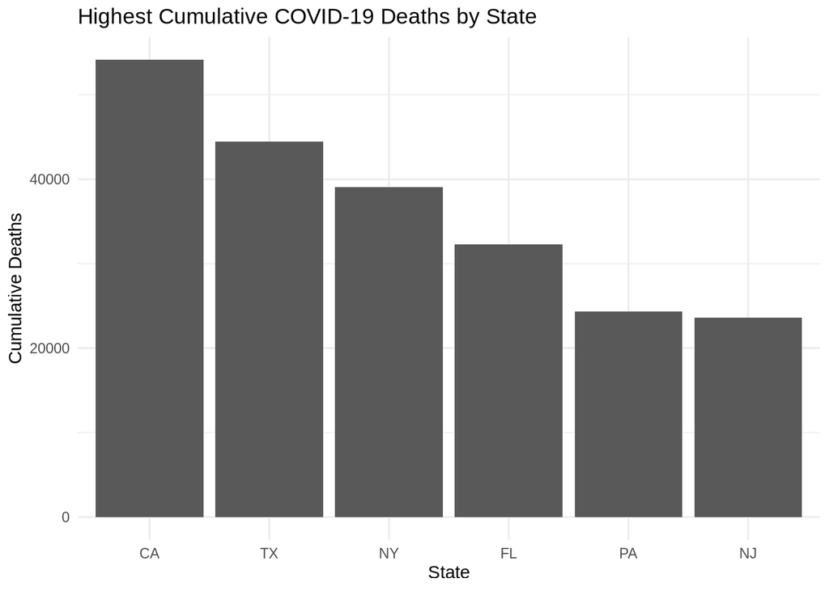

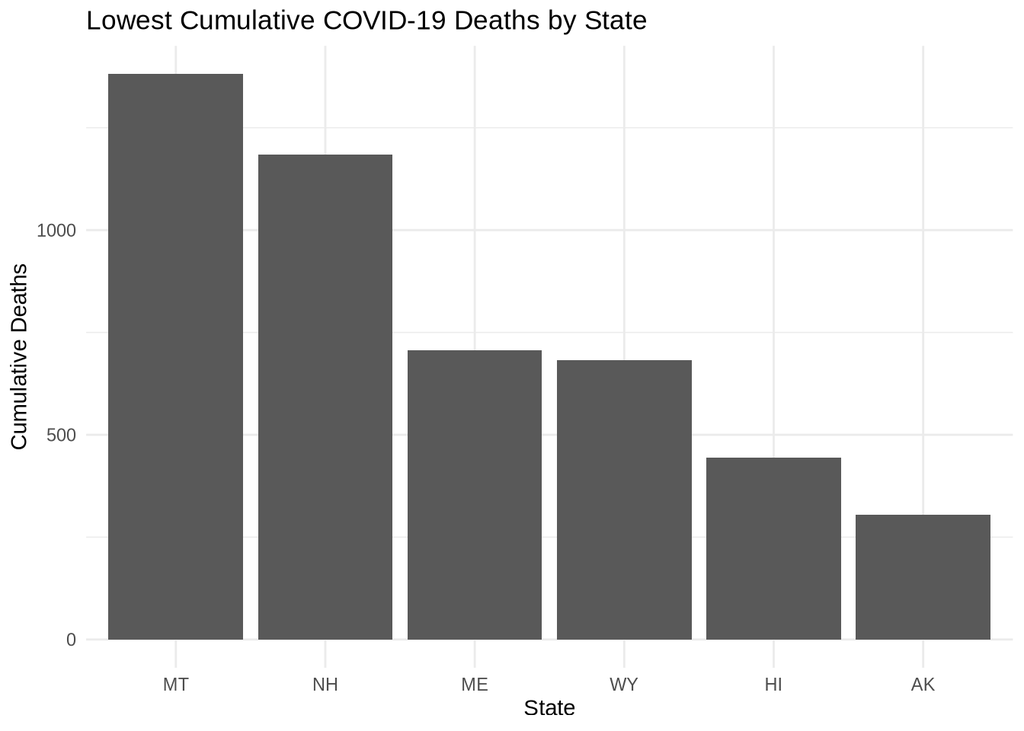

```r
death <- states_data %>%
  group_by(state) %>%
  filter(date == max(date)) %>%
  select(state, death)

death %>%
  arrange(desc(death)) %>%
  head() %>%
  ggplot(death, mapping = aes(x = reorder(state, -death), y = death)) +
  geom_bar(stat = "identity") + theme_minimal() +
  labs(
    title = "Highest Cumulative COVID-19 Deaths by State",
    x = "State",
    y = "Cumulative Deaths"
  )

death %>%
  filter(!state %in% c("AS","GU","MP","VI", "VT", "DC")) %>% #removing included territories
  arrange(desc(death)) %>%
  tail() %>%
  ggplot(death, mapping = aes(x = reorder(state, -death), y = death)) +
  geom_bar(stat = "identity") + theme_minimal() +
  labs(
    title = "Lowest Cumulative COVID-19 Deaths by State",
    x = "State",
    y = "Cumulative Deaths"
  )
```

## Data Cleaning

After our EDA we decided on exploring the data for Washington and Alabama. We chose these states because Washington and Alabama were polar opposites in the amount of observations with Washington having the most and Alabama having the least, along with their similarities in their populations according to the 2020 Census, we decided to use these two states.

```r
AL <- states_data %>%
  filter(state == "AL")

WA <- states_data %>%
  filter(state == "WA")
```

In our EDA we also saw that many of our variables had an overwhelming amount of missing data. We found out that not all states reported all the variables included. We decided to calculate the proportion of missing values in each column, but we only kept columns that had 35% or fewer values are missing. After that the two datasets had different amounts of variables so we decided to individually remove the variables that were outside the scope of our project. We then filtered out variables that contained constant data.

```r
AL <- AL %>%
  select(which(colMeans(is.na(.)) <= 0.35),"death",
         "recovered","onVentilatorCumulative",
         -state,-hash,-checkTimeEt,-dateChecked,
         -hospitalizedCurrently,-hospitalizedCumulative,
         -probableCases,-dateModified,-checkTimeEt,
         -lastUpdateEt,-negative)
AL <- AL %>% select_if(~ length(unique(.)) > 1)

WA <- WA %>%
   select(which(colMeans(is.na(.)) <= 0.35),"death",
         "recovered",,"onVentilatorCumulative")
WA <- WA %>% select_if(~ length(unique(.)) > 1)
```

To ensure both datasets have the same variables, we see which of those variables overlap and then only select them for both of the datasets.

```r
common_columns <- intersect(names(AL), names(WA))
common_columns
```

```
##  [1] "date"                     "positive"
##  [3] "totalTestResults"         "death"
##  [5] "hospitalized"             "positiveCasesViral"
##  [7] "positiveIncrease"         "total"
##  [9] "totalTestResultsIncrease" "posNeg"
## [11] "deathIncrease"            "hospitalizedIncrease"
```

```r
# Subset each data frame to keep only the common columns
AL <- AL %>% select(all_of(common_columns))
WA <- WA %>% select(all_of(common_columns))
```

Once the variables are finalized for both `AL` and `WA` we want to see the proportion of missing values for each variable with the `vis_miss` function.

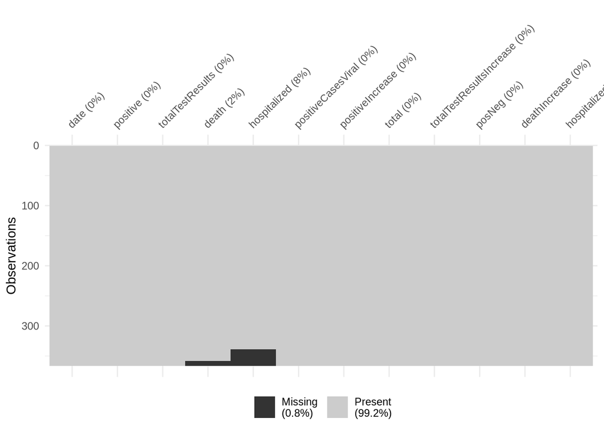

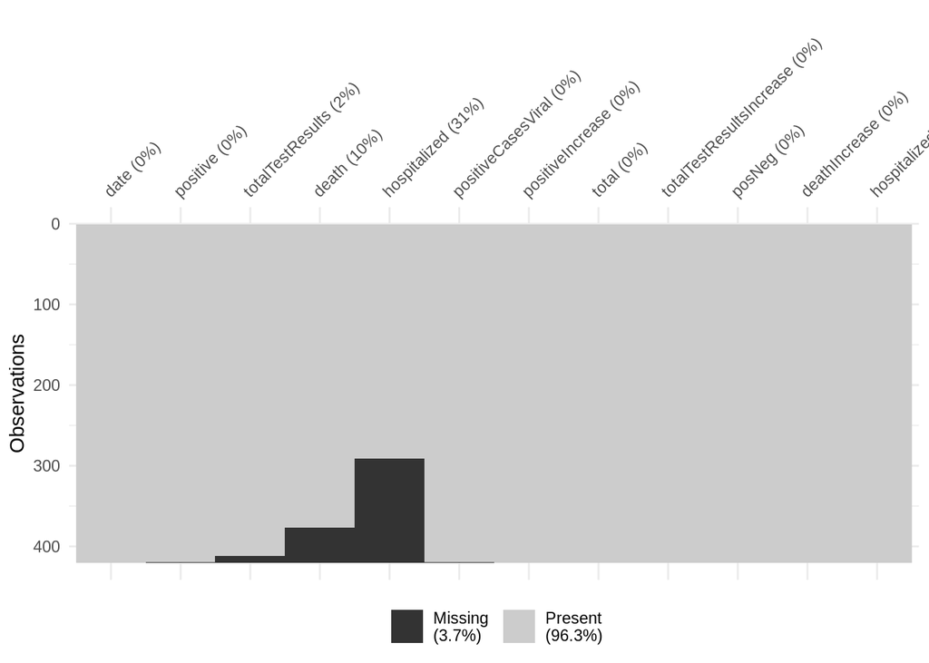

```r
vis_miss(AL)
vis_miss(WA)
```

```r
set.seed(123)

imputed_AL <- mice(AL%>%select(-date), m = 5, method = 'pmm', maxit = 50, seed = 500)
AL_complete <- complete(imputed_AL)

imputed_WA <- mice(WA%>%select(-date), m = 5, method = 'pmm', maxit = 50, seed = 500)
WA_complete <- complete(imputed_WA)
```

We intially removed the date column from the imputation since dates are not imputed, but we later added it back after the imputation.

```r
AL_complete$date <- AL$date
WA_complete$date <- WA$date

WA_complete <- WA_complete %>% drop_na(positive, positiveCasesViral)
```

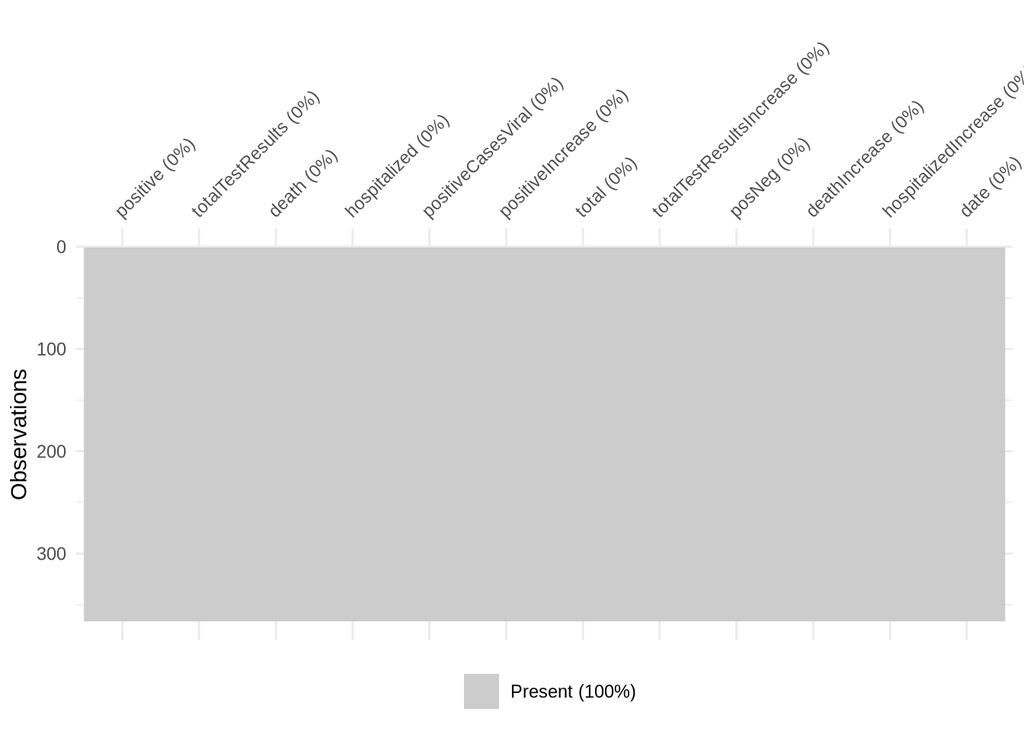

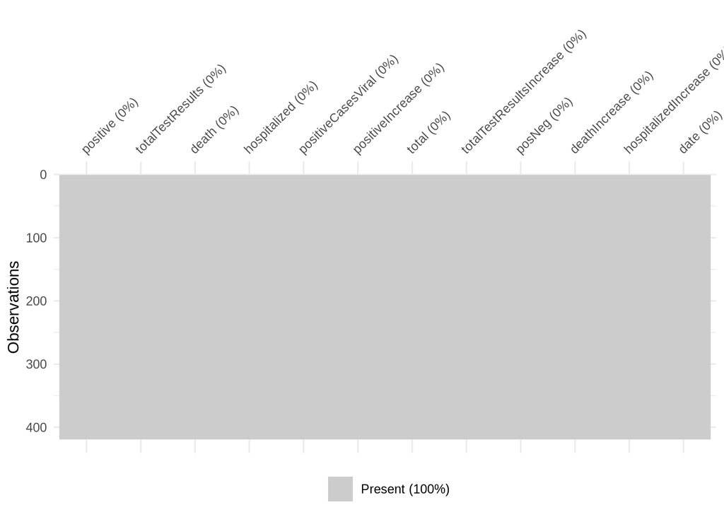

```r
vis_miss(AL_complete)
vis_miss(WA_complete)
```

We no longer have missing data! Earlier we made note that Washington and Alabama did not have the same amount of observations so now we’ll see what day they began to report COVID data.

```r
WA$date %>% tail()%>% kable()
```

| x |
| --- |
| 20200118 |
| 20200117 |
| 20200116 |
| 20200115 |
| 20200114 |
| 20200113 |

```r
AL$date %>% tail() %>% kable()
```

| x |
| --- |
| 20200312 |
| 20200311 |
| 20200310 |
| 20200309 |
| 20200308 |
| 20200307 |

```r
nrow(AL_complete)
```

```
## [1] 366
```

```r
nrow(WA_complete)
```

```
## [1] 419
```

Now we’re converting `date` into a YYYY-MM-DD date format. Then a baseline date (2020-01-01) is set so we’re able to compare the data sets more easily. We do this to easily compute the amount of days that have been passed since the baseline date.

```r
# Convert date column to Date format
AL_complete$date <- as.Date(as.character(AL_complete$date), format = "%Y%m%d")
WA_complete$date <- as.Date(as.character(WA_complete$date), format = "%Y%m%d")

# Set the baseline date
baseline_date <- as.Date("2020-01-01")

# Compute days since the baseline date
AL_complete$daysSinceStart <- as.numeric(AL_complete$date - baseline_date)
WA_complete$daysSinceStart <- as.numeric(WA_complete$date - baseline_date)
```

## E.D.A of Cleaned Data

#### Correlation Plot

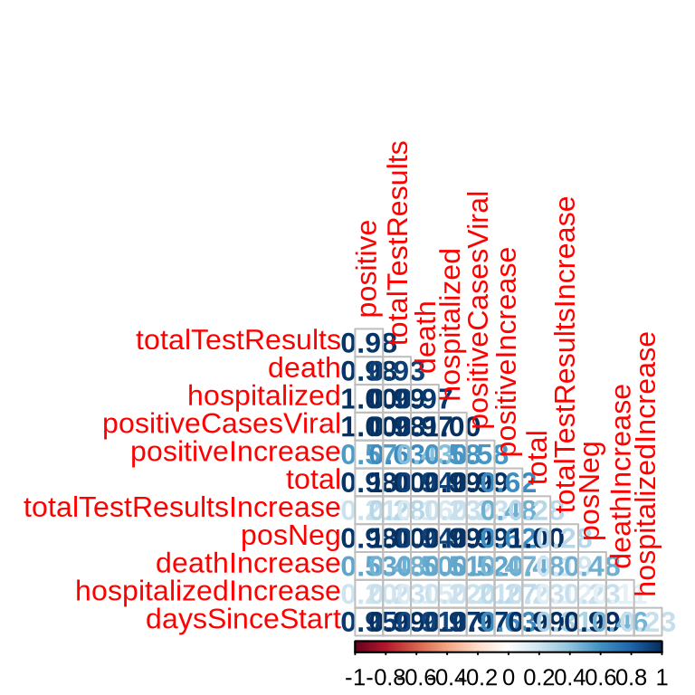

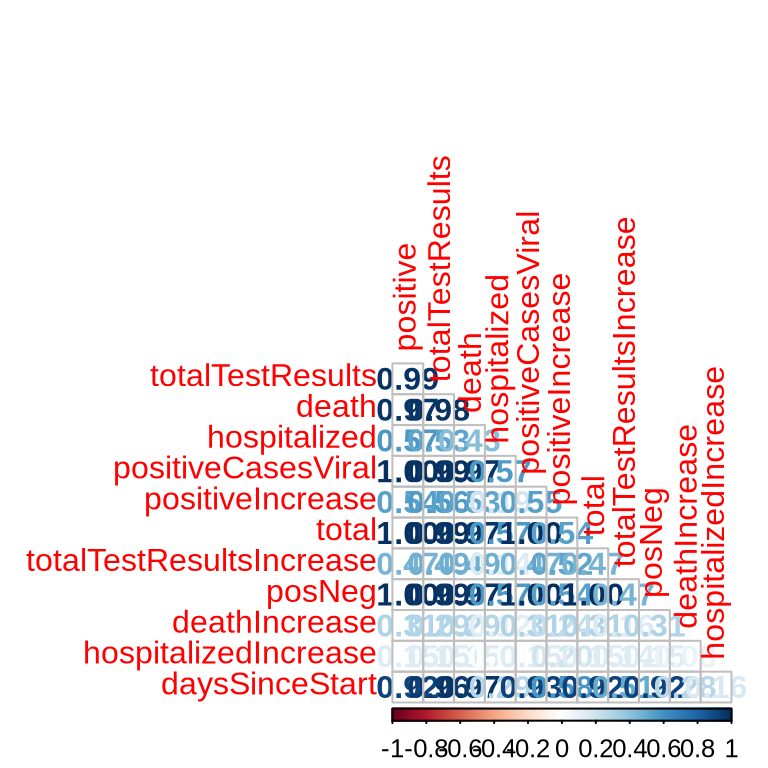

```r
library(corrr)
library(corrplot)
AL_corr <- AL_complete %>%
  select(-date) %>%
  cor() %>%
  corrplot(type = "lower", diag = F, method = "number")

WA_corr <- WA_complete %>%
  select(-date) %>%
  cor() %>%
  corrplot(type = "lower", diag = F, method = "number")
```

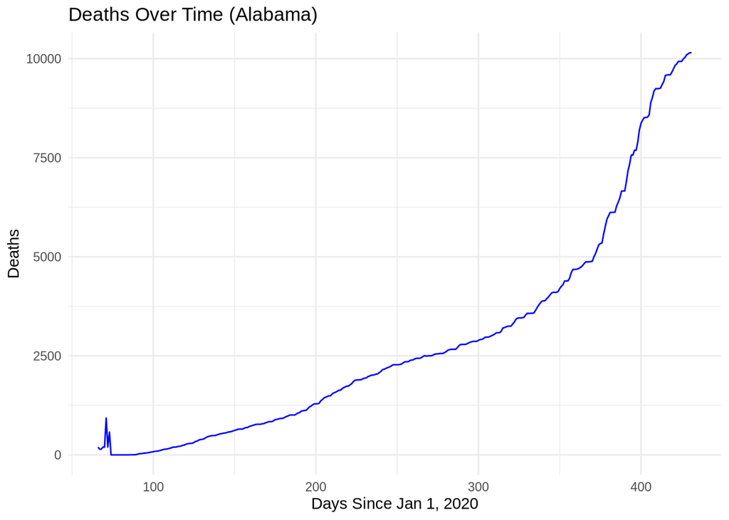

```r
# Deaths Over Time Visualization

# Plot for Alabama
ggplot(AL_complete, aes(x = daysSinceStart, y = death)) +
  geom_line(color = "blue") +
  labs(title = "Deaths Over Time (Alabama)",
       x = "Days Since Jan 1, 2020", y = "Deaths") +
  theme_minimal()
```

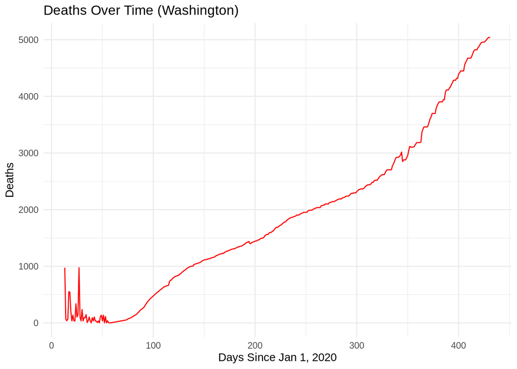

```r
# Plot for Washington
ggplot(WA_complete, aes(x = daysSinceStart, y = death)) +
  geom_line(color = "red") +
  labs(title = "Deaths Over Time (Washington)",
       x = "Days Since Jan 1, 2020", y = "Deaths") +
  theme_minimal()
```

## Model Fitting

```r
# Fit the GAM for the AL_complete data using the selected variables from LASSO
gam_AL <- gam(death ~ s(positive) + s(totalTestResults) + s(hospitalized) +
                      s(positiveCasesViral) +
                      s(daysSinceStart),
              data = AL_complete,
              family = poisson())
summary(gam_AL)
```

[output not shown]

[output not shown]

```
##
## Family: poisson
## Link function: log
##
## Formula:
## death ~ s(positive) + s(totalTestResults) + s(hospitalized) +
##     s(positiveCasesViral) + s(daysSinceStart)
##
## Parametric coefficients:
##             Estimate Std. Error z value Pr(>|z|)
## (Intercept)  7.27397    0.00251    2898   <2e-16 ***
## ---
## Signif. codes:  0 '***' 0.001 '**' 0.01 '*' 0.05 '.' 0.1 ' ' 1
##
## Approximate significance of smooth terms:
##                         edf Ref.df Chi.sq p-value
## s(positive)           8.996  9.000  197.8  <2e-16 ***
## s(totalTestResults)   8.798  8.986  247.3  <2e-16 ***
## s(hospitalized)       8.996  9.000 1972.9  <2e-16 ***
## s(positiveCasesViral) 8.954  8.998  128.3  <2e-16 ***
## s(daysSinceStart)     8.943  8.997  672.4  <2e-16 ***
## ---
## Signif. codes:  0 '***' 0.001 '**' 0.01 '*' 0.05 '.' 0.1 ' ' 1
##
## R-sq.(adj) =  0.999   Deviance explained = 99.6%
## UBRE = 9.8892  Scale est. = 1         n = 366
```

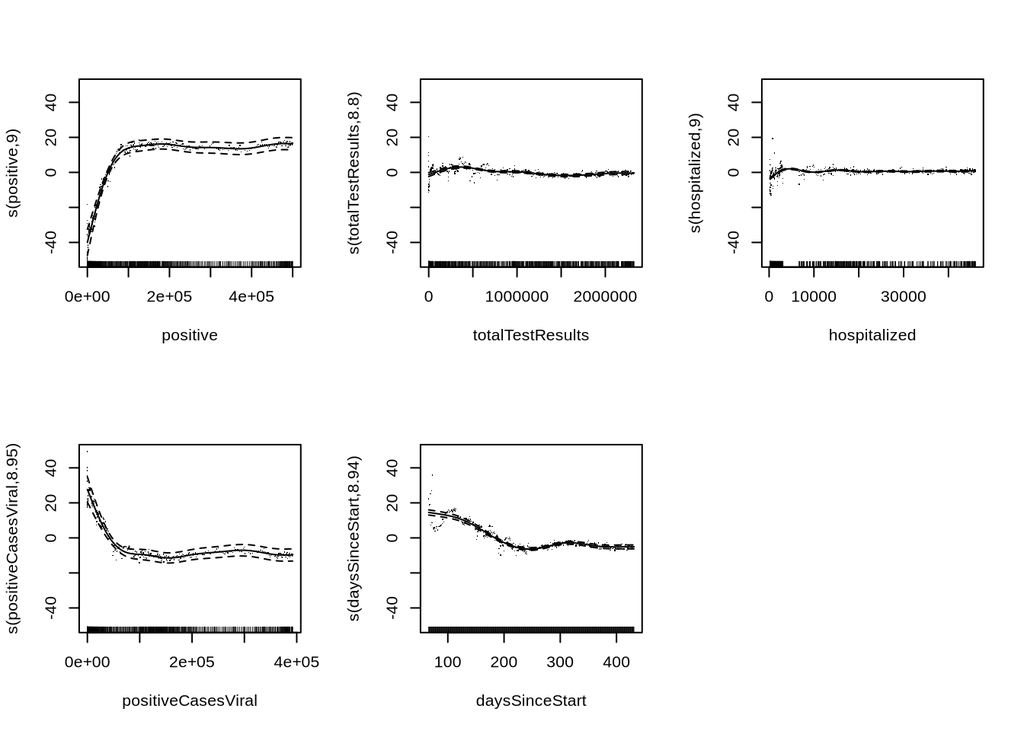

```r
# Plot the smooths
plot(gam_AL, pages = 1, residuals = TRUE, rug = TRUE)
```

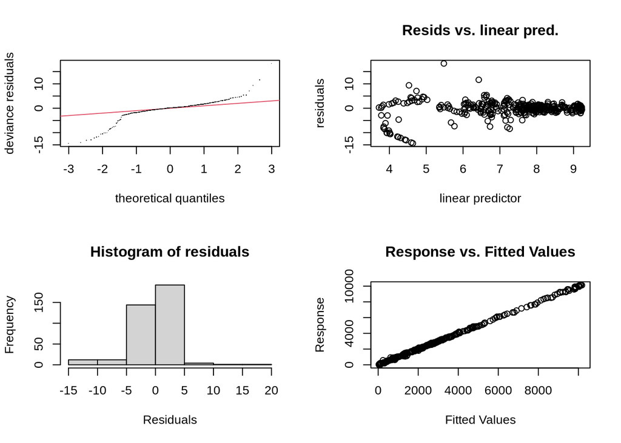

```
##
## Method: UBRE   Optimizer: outer newton
## full convergence after 14 iterations.
## Gradient range [-1.818781e-06,7.421709e-06]
## (score 9.88924 & scale 1).
## Hessian positive definite, eigenvalue range [1.11509e-06,0.00110459].
## Model rank =  46 / 46
##
## Basis dimension (k) checking results. Low p-value (k-index<1) may
## indicate that k is too low, especially if edf is close to k'.
##
##                         k'  edf k-index p-value
## s(positive)           9.00 9.00    0.42  <2e-16 ***
## s(totalTestResults)   9.00 8.80    0.39  <2e-16 ***
## s(hospitalized)       9.00 9.00    0.50  <2e-16 ***
## s(positiveCasesViral) 9.00 8.95    0.42  <2e-16 ***
## s(daysSinceStart)     9.00 8.94    0.44  <2e-16 ***
## ---
## Signif. codes:  0 '***' 0.001 '**' 0.01 '*' 0.05 '.' 0.1 ' ' 1
```

```r
# Check GAM diagnostics
gam.check(gam_AL)
```

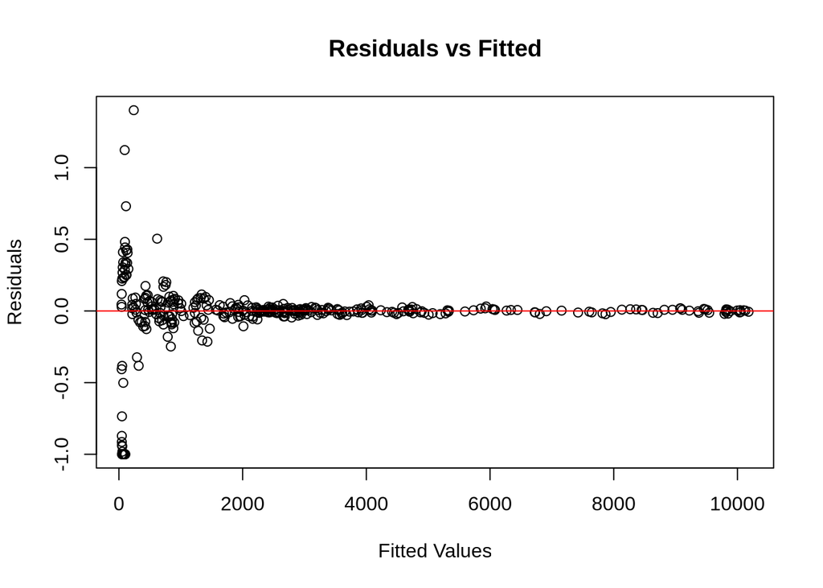

```r
# Plot residuals vs fitted
plot(gam_AL$residuals ~ gam_AL$fitted.values,
     xlab = "Fitted Values", ylab = "Residuals", main = "Residuals vs Fitted")
abline(h = 0, col = "red")
```

```r
# Fit the GAM for the WA_complete data using the selected variables from LASSO
gam_WA <- gam(death ~ s(daysSinceStart) + s(positive) + s(total) + s(positiveIncrease),
              data = WA_complete,
              family = poisson())

summary(gam_WA)
```

[output not shown]

[output not shown]

```
##
## Family: poisson
## Link function: log
##
## Formula:
## death ~ s(daysSinceStart) + s(positive) + s(total) + s(positiveIncrease)
##
## Parametric coefficients:
##             Estimate Std. Error z value Pr(>|z|)
## (Intercept) 6.989528   0.002555    2736   <2e-16 ***
## ---
## Signif. codes:  0 '***' 0.001 '**' 0.01 '*' 0.05 '.' 0.1 ' ' 1
##
## Approximate significance of smooth terms:
##                       edf Ref.df   Chi.sq  p-value
## s(daysSinceStart)   8.986  9.000 7216.024  < 2e-16 ***
## s(positive)         8.938  8.944  111.216  < 2e-16 ***
## s(total)            1.056  1.056   28.219 7.73e-07 ***
## s(positiveIncrease) 2.015  2.541    7.825   0.0338 *
## ---
## Signif. codes:  0 '***' 0.001 '**' 0.01 '*' 0.05 '.' 0.1 ' ' 1
##
## R-sq.(adj) =  0.997   Deviance explained = 98.5%
## UBRE = 16.977  Scale est. = 1         n = 419
```

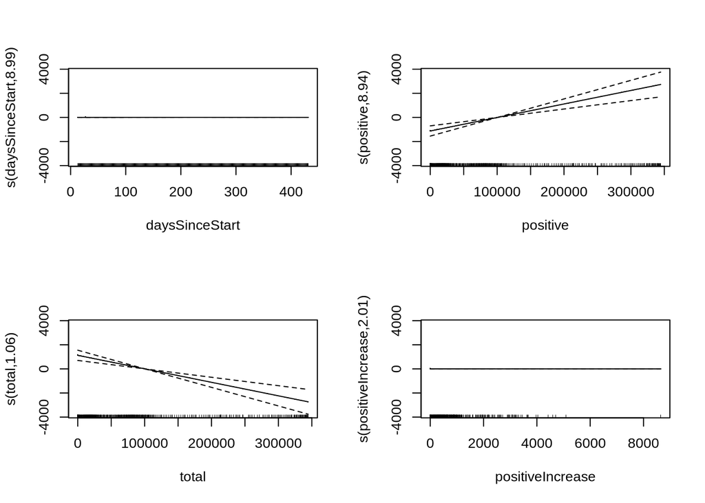

```r
# Plot the smooths
plot(gam_WA, pages = 1, residuals = TRUE, rug = TRUE)
```

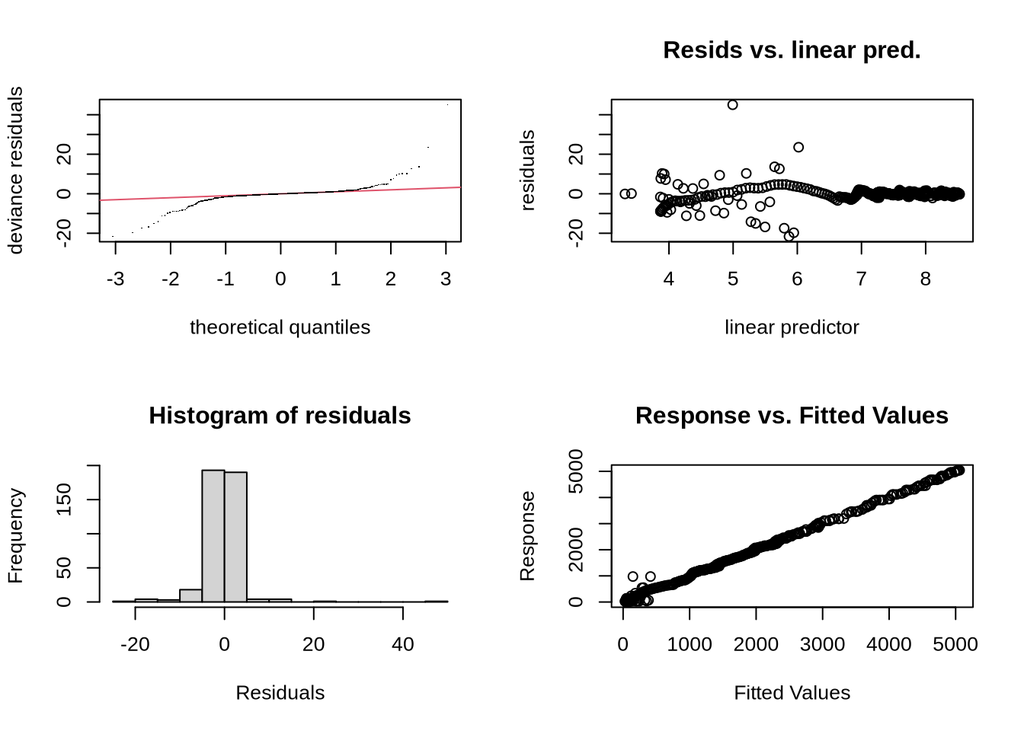

```
##
## Method: UBRE   Optimizer: outer newton
## full convergence after 9 iterations.
## Gradient range [-3.498542e-05,5.844296e-05]
## (score 16.97717 & scale 1).
## eigenvalue range [-2.574822e-05,0.00208067].
## Model rank =  37 / 37
##
## Basis dimension (k) checking results. Low p-value (k-index<1) may
## indicate that k is too low, especially if edf is close to k'.
##
##                       k'  edf k-index p-value
## s(daysSinceStart)   9.00 8.99    0.82  <2e-16 ***
## s(positive)         9.00 8.94    0.87    0.01 **
## s(total)            9.00 1.06    0.87    0.01 **
## s(positiveIncrease) 9.00 2.01    1.06    0.92
## ---
## Signif. codes:  0 '***' 0.001 '**' 0.01 '*' 0.05 '.' 0.1 ' ' 1
```

```r
# Check GAM diagnostics
gam.check(gam_WA)
```

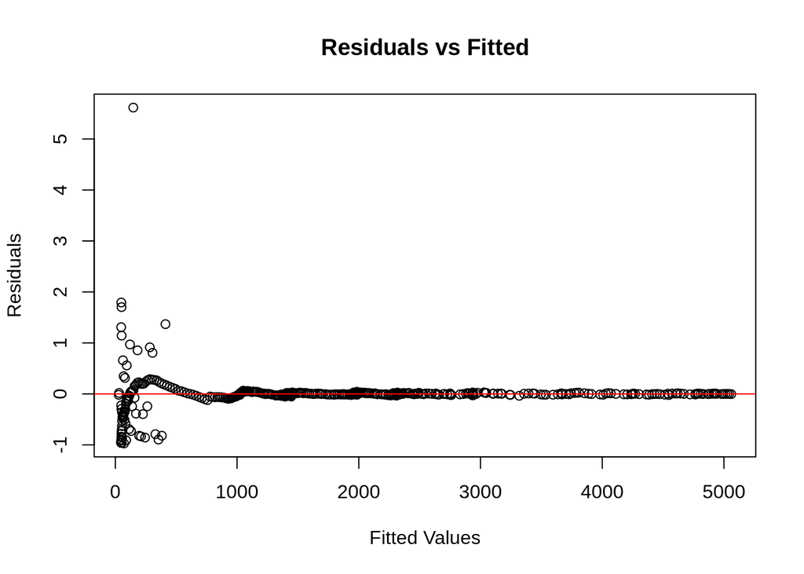

```r
# Plot residuals vs fitted
plot(gam_WA$residuals ~ gam_WA$fitted.values,
     xlab = "Fitted Values", ylab = "Residuals", main = "Residuals vs Fitted")
abline(h = 0, col = "red")
```

### Training and Testing

#### Alabama

```r
AL_train_index <- sample(1:nrow(AL_complete), size = 0.7 * nrow(AL_complete)) # 70% training
AL_train_data <- AL_complete[AL_train_index, ]
AL_test_data <- AL_complete[-AL_train_index, ]

trained_gam_AL <- gam(death ~ s(positive) + s(totalTestResults) + s(hospitalized) +
                s(positiveCasesViral) + s(deathIncrease) +
                s(daysSinceStart), data = AL_train_data)

AL_predictions <- predict(trained_gam_AL, newdata = AL_test_data)
```

```r
# Mean Squared Error (MSE)
mse <- mean((AL_test_data$death - AL_predictions)^2)

# Root Mean Squared Error (RMSE)
rmse <- sqrt(mse)

# Mean Absolute Error (MAE)
mae <- mean(abs(AL_test_data$death - AL_predictions))

# Print results
print(list(MSE = mse, RMSE = rmse, MAE = mae))
```

```
## $MSE
## [1] 3109.586
##
## $RMSE
## [1] 55.76366
##
## $MAE
## [1] 35.0366
```

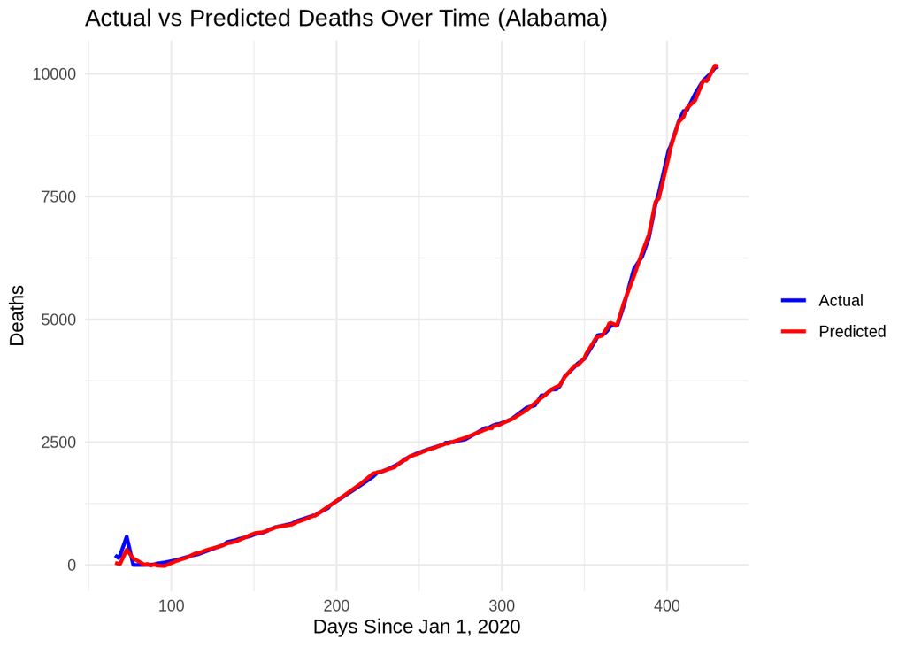

```r
# Plot of Actual and Predicted Deaths in Alabama over Time
plot_data <- data.frame(
  daysSinceStart = AL_test_data$daysSinceStart,
  Actual = AL_test_data$death,
  Predicted = AL_predictions
)


ggplot(plot_data, aes(x = daysSinceStart)) +
  geom_line(aes(y = Actual, color = "Actual"), size = 1) +
  geom_line(aes(y = Predicted, color = "Predicted"), size = 1) +
  labs(title = "Actual vs Predicted Deaths Over Time (Alabama)",
       x = "Days Since Jan 1, 2020", y = "Deaths") +
  scale_color_manual(values = c("Actual" = "blue", "Predicted" = "red")) +
  theme_minimal() +
  theme(legend.title = element_blank())
```

#### Washington

```r
WA_train_index <- sample(1:nrow(WA_complete), size = 0.7 * nrow(WA_complete)) # 70% training
WA_train_data <- WA_complete[WA_train_index, ]
WA_test_data <- WA_complete[-WA_train_index, ]

trained_gam_WA <- gam(death ~ s(positive) + s(total) + s(daysSinceStart),
                      data = WA_train_data)

WA_predictions <- predict(trained_gam_WA, newdata = WA_test_data)
```

```r
# Mean Squared Error (MSE)
WA_mse <- mean((WA_test_data$death - WA_predictions)^2)

# Root Mean Squared Error (RMSE)
WA_rmse <- sqrt(WA_mse)

# Mean Absolute Error (MAE)
WA_mae <- mean(abs(WA_test_data$death - WA_predictions))

# Print results
print(list(MSE = WA_mse, RMSE = WA_rmse, MAE = WA_mae))
```

```
## $MSE
## [1] 6492.894
##
## $RMSE
## [1] 80.5785
##
## $MAE
## [1] 28.9605
```

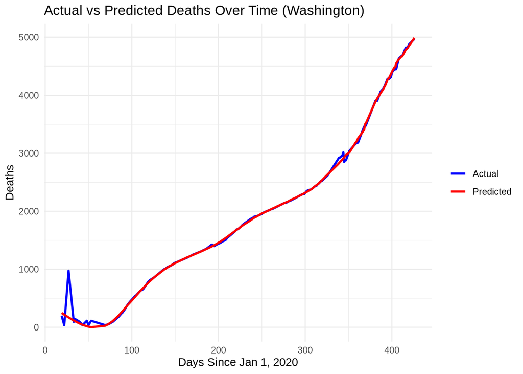

```r
# Plot of Actual and Predicted Deaths in WASHINGTON over Time
WA_plot_data <- data.frame(
  daysSinceStart = WA_test_data$daysSinceStart,
  Actual = WA_test_data$death,
  Predicted = WA_predictions
)


ggplot(WA_plot_data, aes(x = daysSinceStart)) +
  geom_line(aes(y = Actual, color = "Actual"), size = 1) +
  geom_line(aes(y = Predicted, color = "Predicted"), size = 1) +
  labs(title = "Actual vs Predicted Deaths Over Time (Washington)",
       x = "Days Since Jan 1, 2020", y = "Deaths") +
  scale_color_manual(values = c("Actual" = "blue", "Predicted" = "red")) +
  theme_minimal() +
  theme(legend.title = element_blank())
```

## Sources

Ciotti, M., Ciccozzi, M., Terrinoni, A., Jiang, W. C., Wang, C. B., & Bernardini, S. (2020). The COVID-19 pandemic. *Critical Reviews in Clinical Laboratory Sciences*, *57*(6), 365–388. https://doi.org/10.1080/10408363.2020.1783198

Erwin, P. C., Mucheck, K. W., & Brownson, R. C. (2021). Different Responses to COVID-19 in Four US States: Washington, New York, Missouri, and Alabama. American journal of public health, 111(4), 647–651. https://doi.org/10.2105/AJPH.2020.306111